# Stage 2c: the refined linked core

Four refinements at zero cost in degrees of freedom — closing the monetary loop, and the fifth refinement that had to be thrown away

## Summary

Stage 2c refines stage 2b’s eleven-country system. Its defining property is that **the refinements are free**: `k` stays at 76 against `T = 98`, so `df = 22` in both systems. Every stage-3 block in this project bought structure with degrees of freedom — stage 3a went to `df = 15`, then 6; stage 3b to 8; stage 3c could not be validated at all. Stage 2c is the one extension that can be compared against its predecessor with no size caveat attached.

Five refinements were estimated. **Four are adopted; one is rejected.**

| # | Refinement | Verdict |
| --- | --- | --- |
| 1 | `prices` gains `<iso2>_gdp` (Phillips curve) | **Adopted.** The monetary loop closes: `ea_policy_rate` goes from reaching **no price variable at all** to reaching every one. 10 of 11 correctly signed. |
| 2 | `foreign_demand` over partner **imports** | **Adopted.** Largely a rescaling — partner imports are ~1.8x as volatile as partner GDP — though the US index genuinely changes. |
| 3 | Model the **spread**; `long_rate` becomes an identity | **Adopted.** Motivation confirmed emphatically: all eleven stage-2b policy-rate loadings straddle zero. One stated benefit is not delivered. |
| 4 | `consumption` gains `<iso2>_long_rate` | **Adopted, weak.** 8 of 11 correctly signed, and the loadings are small. |
| 5 | `imports` gains `<iso2>_exports` (import content) | **Rejected.** Collapses the domestic-demand elasticity in **9 of 11** countries while halving the imports equations’ RMSE. |

The recommended system is clean on every sampler diagnostic: 0 acceptance-rate flags of 68, 0 lag-stability flags, and 8 sign-check failures of 55.

**The most useful thing this stage produced is the rejection.** Refinement 5 improves in-sample fit dramatically and breaks the model, and it took three separate diagnostics — an elasticity comparison, a re-estimation without it, and a sign-check count corrected for absent terms — to see that. Section 4 is the substance of this report.

## 1. Four refinements, none of which costs a degree of freedom

All three systems are the same size. Only the identity count moves.

| system | stochastic | identities | endogenous | exogenous | k | T_obs | df | seconds |
| --- | --- | --- | --- | --- | --- | --- | --- | --- |
| stage 2b | 68 | 35 | 103 | 7 | 76 | 98 | 22 | 213.5 |
| stage 2c (recommended, 4 refinements) | 68 | 46 | 114 | 7 | 76 | 98 | 22 | 287.7 |
| stage 2c + import content (rejected) | 68 | 46 | 114 | 7 | 76 | 98 | 22 | 294.1 |

The equation *count* is unchanged at 68 stochastic, because the long-rate level equation is **swapped** for a spread equation rather than added to. Identities go 35 → 46: eleven new `<iso2>_long_rate == 1*<iso2>_spread + 1*<policy rate>`.

Why each refinement is free:

- **1 and 4** add only *contemporaneous endogenous* regressors. `k = 1 + (one lag per stochastic equation) + (exogenous)`, and a contemporaneous endogenous term is none of those three.
- **2** re-weights an existing identity; the weights are fixed trade shares.
- **3** is `k`-neutral by construction: the long rate loses its own lag column and the spread gains one.

The second `k` constraint is slack too. `draw_omega_j()` draws `riwish(T - k, .)` on a matrix that is `(endogenous regressors in that equation + 1)` square, so the binding requirement here is `df >= 3` against `df = 22`.

### 1.1 A silent identity violation, found and closed off

Stage 2c is the first configuration to put the **US** in `spread_countries`, and that exposed a live trap. `<iso2>_long_rate == <iso2>_spread + <policy rate>` is written in two places that must agree: the identity, and the `<iso2>_spread` series the panel builder constructs. The identity resolved `us_policy_rate` for the US under `policy_rule = TRUE`; the panel builder’s scalar default subtracted `ea_policy_rate` for everyone. **The US identity was violated by the entire EA–US policy-rate gap — up to 3.25 percentage points — and koma said nothing**, because koma has no identity-consistency check at all.

Both sides now resolve through one `policy_rate_map()`, and `stage2_preflight()` gained a ninth check, `identity_consistency()`, which does the arithmetic koma does not: it recomputes every identity from the panel and reports its worst absolute error, in level space for the `rate`/`none` rate family and in rate space for everything else. On the stage-2c panel, 23 exact identities hold to a worst error of 1.05e-13. `<iso2>_gdp` and `<iso2>_domestic_demand` are reported but never flagged — the first holds only up to the statistical discrepancy, the second is deliberately inexact under `include_government = FALSE`.

## 2. The loop that was open

`CLAUDE.md` has recorded since stage 1 that “making a variable endogenous does not give it a transmission channel”. Stage 2b gave `ea_policy_rate` its own Taylor rule; `reports/stage2_spillovers.qmd` §4 then found no monetary transmission at all, and §7.2 recorded the sanity check failing as a genuine property of the fitted system rather than a code defect.

`contemporaneous_reachability()` says exactly where the break was.

Endogenous variables reachable from ea_policy_rate through contemporaneous links.

| system | endogenous | reached | price_variables_reached |
| --- | --- | --- | --- |
| stage 2b | 103 | 91 | 0 |
| stage 2c (recommended) | 114 | 114 | 12 |

Stage 2b’s policy rate reaches 91 of 103 endogenous variables — **and not one of them is a price**. It is even reachable from *itself*, through the Taylor rule’s `ea_gdp` term, so a naive “is the loop closed?” test would have passed. The rule’s **output** term was closed all along; its **inflation** term was the open one, responding to a variable nothing the rule did could influence.

The price equation was the break. In stage 2b its contemporaneous endogenous regressor set was empty — own lag, COVID dummies, `eur_usd` and `oil_price`, all exogenous. Adding `<iso2>_gdp` closes it, and stage 2c’s policy rate reaches **all 114** endogenous variables, all 12 price variables included.

There is a second, mechanical confirmation. An equation with no contemporaneous endogenous regressor gets no Metropolis step, so koma reports `count_accepted = NA` for it:

The eleven stage-2b equations with no Metropolis step were exactly the price equations.

| system | with_metropolis_step | without | which_without |
| --- | --- | --- | --- |
| stage 2b | 57 | 11 | at_prices, be_prices, de_prices, gr_prices, es_prices, fr_prices, ie_prices, it_prices, nl_prices, pt_prices, us_prices |
| stage 2c | 68 | 0 | — |

**Structure is not magnitude.** Reachability says a path exists, not that anything travels along it — §4.5 and §8 put numbers on that.

## 3. Estimation and the sampler

Equations outside the 20-60% acceptance band at each tune_tau_system() round.

| system | iteration 0 | iteration 1 | iteration 2 | iteration 3 |
| --- | --- | --- | --- | --- |
| stage 2c + import content | 14 | 6 | 1 | 0 |
| stage 2c (recommended) | 23 | 6 | 0 | NA |

Both configurations converge, the recommended one in two rounds. Two things about that table are worth stating rather than glossing.

First, the five-refinement run’s iteration 0 flags **14** where a separately estimated untuned fit of the same system flagged 9. That is not a change: `model_identification()` consumes RNG, so two estimations of the same system give slightly different acceptance rates, and a dozen equations sit within a percentage point of the 60% boundary. Reading 9 → 14 as a finding would be reading noise.

Second, the tuned recommended system has 0 equations outside the band and 0 lag-stability flags. The sampler is not the explanation for anything in what follows.

## 4. Refinement 5, and why it had to go

This is the substance of the report, so it is worth stating the shape of the argument before the tables. The import-content term — giving `<iso2>_imports` a contemporaneous `<iso2>_exports` regressor, on the sound reasoning that exports require imported intermediates — passes its own sign check in **11 of 11 countries** and improves the imports equations’ in-sample fit **dramatically**. It is still wrong, and three separate diagnostics were needed to establish that.

### 4.1 The sign check saw one failure; nine elasticities were being gutted

imports ~ domestic_demand. The elasticity the equation exists to measure.

| equation | stage 2b | with import content | recommended |
| --- | --- | --- | --- |
| at_imports | 0.450 | -0.104 | 0.274 |
| be_imports | 0.849 | 0.621 | 0.832 |
| de_imports | 0.382 | 0.049 | 0.320 |
| es_imports | 1.705 | 1.569 | 1.742 |
| fr_imports | 1.245 | 0.638 | 1.215 |
| gr_imports | 1.000 | 0.833 | 0.862 |
| ie_imports | 0.650 | 0.699 | 0.663 |
| it_imports | 1.213 | 0.803 | 1.278 |
| nl_imports | 1.027 | 1.126 | 1.013 |
| pt_imports | 1.491 | 1.306 | 1.503 |
| us_imports | 1.798 | 1.237 | 1.782 |

With the term in, nine of eleven elasticities fall and two are destroyed: Germany from 0.382 to **0.049**, Austria from 0.450 to **−0.104**. Only Austria crosses zero, so `sign_checks()` — which looks at one coefficient at a time — reported exactly one failure while most of the block was being hollowed out.

### 4.2 The improved fit is the symptom, not the reassurance

In-sample RMSE of the imports equations. Ratio below 1 is a better fit.

| equation | stage 2b RMSE | with import content | ratio |
| --- | --- | --- | --- |
| be_imports | 1.8145 | 0.6471 | 0.3566 |
| nl_imports | 1.8202 | 0.9271 | 0.5093 |
| es_imports | 1.9303 | 1.0135 | 0.5251 |
| ie_imports | 4.7966 | 3.4560 | 0.7205 |
| fr_imports | 1.5103 | 1.1269 | 0.7461 |
| at_imports | 2.1432 | 1.6590 | 0.7741 |
| it_imports | 1.7637 | 1.3790 | 0.7819 |
| de_imports | 1.9917 | 1.5780 | 0.7923 |
| us_imports | 1.3460 | 1.1092 | 0.8241 |
| pt_imports | 2.0916 | 1.7440 | 0.8338 |
| gr_imports | 4.2369 | 3.8348 | 0.9051 |

Belgium’s imports equation fits **2.8x better** and the Netherlands’ **2.0x better**, while their structural elasticities fall. That is what a contemporaneous regressor correlated with the dependent variable does, whether or not it belongs there. Had this stage been judged on in-sample fit — the five-refinement system fits better in 77% of shared equations — the term would have been adopted.

### 4.3 Removing it recovers every elasticity, and repairs equations it never touched

Sign-check failures. Both columns are over the same 55 checks.

| check | with_import_content | recommended |
| --- | --- | --- |
| import_elasticity_positive | 1 | 0 |
| phillips_curve_positive | 3 | 1 |
| consumption_rate_channel_negative | 5 | 3 |
| spread_loads_on_prices_positive | 3 | 3 |
| mpc_in_0_1 | 0 | 1 |
| TOTAL (of 55 comparable checks) | 12 | 8 |

All eleven elasticities move back toward their stage-2b values (Germany 0.320 against 0.382, France 1.215 against 1.245, the US 1.782 against 1.798) — the same recovery stage 3a saw when the import-price term was lagged, “0.386 vs 0.382”.

The wider effect is the interesting one. Removing a term from the **imports** equation repairs two Phillips-curve sign checks and two consumption-rate sign checks, in equations it does not appear in. In a simultaneous system with a system-wide residual covariance, one badly specified equation is not a local problem — which is the other half of a lesson `CLAUDE.md` already carries from stage 3a phase B: “a bad specification in one equation can masquerade as a systemic problem”. Here it masqueraded as two.

The one thing that gets worse is Ireland’s MPC, which crosses from +0.001 to −0.005. Ireland’s consumption–GDP loading is ~0 in all three systems (0.017 in stage 2b), so this is a coefficient that is not identified rather than one that broke; it is reported here rather than explained away.

### 4.4 A reporting trap this exposed

Read naively, `sign_checks(stage2c = TRUE)` reports **19 failures of 66** for the recommended system against **12 of 66** for the rejected one — the opposite of the truth. Eleven of those nineteen are `import_content_positive` scoring `NA`/`FALSE` because the term is not in the model.

That default is right for the stage-3 blocks it was designed for (“a check that could not be evaluated is not a check that passed”) and wrong for a deliberately dropped refinement. `sign_checks(stage2c = )` now takes a subset of `stage2c_refinements()`, and `stage2c_config()` returns the subset it carries.

### 4.5 The monetary loop is closed, and nearly inert

monetary_loop(): policy rate -> long rate -> consumption -> GDP -> prices -> ea_prices -> policy rate.

| iso2 | median | q05 | q95 | share_ge_1 | consumption_long_rate | phillips | taylor |
| --- | --- | --- | --- | --- | --- | --- | --- |
| at | 0 | -0.0002 | 0.0002 | 0 | 0.0315 | 0.0670 | 0.2571 |
| be | 0 | -0.0005 | 0.0003 | 0 | -0.0065 | 0.1233 | 0.2571 |
| de | 0 | -0.0013 | 0.0017 | 0 | -0.0985 | -0.0383 | 0.2571 |
| gr | 0 | -0.0001 | 0.0001 | 0 | -0.1170 | 0.0017 | 0.2571 |
| es | 0 | -0.0010 | 0.0011 | 0 | -0.0059 | 0.2138 | 0.2571 |
| fr | 0 | -0.0008 | 0.0008 | 0 | 0.0306 | 0.0725 | 0.2571 |
| ie | 0 | -0.0001 | 0.0000 | 0 | -0.1240 | 0.0134 | 0.2571 |
| it | 0 | -0.0013 | 0.0010 | 0 | -0.0001 | 0.0500 | 0.2571 |
| nl | 0 | -0.0006 | 0.0004 | 0 | -0.0018 | 0.0065 | 0.2571 |
| pt | 0 | -0.0001 | 0.0000 | 0 | -0.0561 | 0.1132 | 0.2571 |

No draw in any country reaches a round-trip gain of 1, so the loop stage 2c adds is not a stability risk. `CLAUDE.md` warns against reading that as reassurance — “a quiet loop is not necessarily a stable one” — so the per-link means are in the table, and they are the point:

- The **Taylor rule’s** inflation loading is 0.257, positive and sensible, shared by every country.
- The **Phillips curve** link is positive in 9 of the 10 euro-area countries, up to 0.214. Germany is the exception, at -0.038.
- The **consumption rate channel** is the weak link: correctly signed in most countries but tiny, and positive in Austria and France.

A six-link chain of coefficients this small multiplies out to a contemporaneous gain around 1e-5. That is a statement about *within-quarter feedback*, not about whether a monetary shock has any effect over a horizon — the dynamic response accumulates through the lag structure, which is what §8 measures.

## 5. The rate block: from a level equation to a spread equation

The stage-2b long-rate equation against the stage-2c spread equation.

| iso2 | long_rate_own_lag_2b | policy_loading_2b | spans_zero_2b | spread_own_lag_2c |
| --- | --- | --- | --- | --- |
| at | 0.937 | 0.046 | TRUE | 0.936 |
| be | 0.942 | 0.041 | TRUE | 0.958 |
| de | 0.940 | 0.045 | TRUE | 0.933 |
| es | 0.961 | 0.005 | TRUE | 0.983 |
| fr | 0.915 | 0.052 | TRUE | 0.935 |
| gr | 0.945 | -0.049 | TRUE | 0.958 |
| ie | 0.962 | 0.007 | TRUE | 0.968 |
| it | 0.910 | 0.031 | TRUE | 0.957 |
| nl | 0.917 | 0.064 | TRUE | 0.937 |
| pt | 0.964 | -0.013 | TRUE | 0.979 |
| us | 0.926 | 0.015 | TRUE | 0.937 |

The motivation for refinement 3 is confirmed, and more strongly than the design note claimed. **All eleven** stage-2b policy-rate loadings have 90% credible intervals straddling zero, while the long rate’s own lag sits at 0.910–0.964. The level equation was an AR(1) with decoration, and imposing the pass-through at 1 is strictly better than estimating it into insignificance.

One of the four stated benefits does not survive contact with the data. The design note argued that “a spread is stationary where a rate level is not, so the own lag has no unit root to run to”. The stage-2c spread own lags run **0.933–0.983** — as persistent as the levels they replaced, and for Spain (0.961 → 0.983) and Portugal (0.964 → 0.979) more so. The other three arguments are unaffected. The roxygen for `financial_block()` has been corrected to say so.

## 6. What happened to the equations that were already there

Behavioural coefficients only – constants and COVID dummies excluded, since a near-zero stage-2b value makes any relative comparison meaningless.

| set | behavioural_terms | sign_flips |
| --- | --- | --- |
| touched equations (prices, consumption) | 28 | 1 |
| untouched equations | 110 | 7 |

Two behavioural blocks stage 2c does not modify.

| block | equation | estimate_2b | estimate_2c | delta |
| --- | --- | --- | --- | --- |
| MPC (consumption ~ gdp) | at_consumption | 0.771 | 0.801 | 0.030 |
| MPC (consumption ~ gdp) | be_consumption | 0.791 | 0.840 | 0.050 |
| MPC (consumption ~ gdp) | de_consumption | 0.221 | 0.202 | -0.019 |
| MPC (consumption ~ gdp) | es_consumption | 0.872 | 0.865 | -0.007 |
| MPC (consumption ~ gdp) | fr_consumption | 0.861 | 0.830 | -0.030 |
| MPC (consumption ~ gdp) | gr_consumption | 0.614 | 0.423 | -0.191 |
| MPC (consumption ~ gdp) | ie_consumption | 0.017 | -0.005 | -0.022 |
| MPC (consumption ~ gdp) | it_consumption | 0.633 | 0.593 | -0.040 |
| MPC (consumption ~ gdp) | nl_consumption | 0.619 | 0.638 | 0.019 |
| MPC (consumption ~ gdp) | pt_consumption | 0.905 | 0.853 | -0.052 |
| MPC (consumption ~ gdp) | us_consumption | 0.479 | 0.510 | 0.031 |
| investment ~ long_rate | at_investment | -0.183 | -0.232 | -0.050 |
| investment ~ long_rate | be_investment | -0.160 | -0.103 | 0.058 |
| investment ~ long_rate | de_investment | -0.066 | -0.089 | -0.023 |
| investment ~ long_rate | es_investment | -0.017 | -0.001 | 0.016 |
| investment ~ long_rate | fr_investment | 0.007 | -0.011 | -0.018 |
| investment ~ long_rate | gr_investment | 0.019 | -0.014 | -0.033 |
| investment ~ long_rate | ie_investment | -2.535 | -2.720 | -0.185 |
| investment ~ long_rate | it_investment | -0.202 | -0.207 | -0.005 |
| investment ~ long_rate | nl_investment | -0.256 | -0.235 | 0.021 |
| investment ~ long_rate | pt_investment | -0.466 | -0.441 | 0.026 |
| investment ~ long_rate | us_investment | -0.311 | -0.153 | 0.158 |

The MPC is stable and stays inside `(0, 1)` in ten of eleven (Ireland’s is the unidentified one from §4.3), the price equations’ own lags move by at most 0.036, and the investment channel is essentially unchanged. The refinements are not disruptive once refinement 5 is out.

## 7. In-sample fit

Against stage 2b. Both systems estimated on the identical 2000Q1-2024Q4 window.

| measure | recommended | with_import_content |
| --- | --- | --- |
| equations where stage 2c fits better | 34 of 57 (60%) | 44 of 57 (77%) |
| median RMSE ratio, all shared equations | 0.9992 | 0.9954 |
| median RMSE ratio, imports equations | 1.0001 | 0.7741 |
| median RMSE ratio, everything except imports | 0.9983 | 0.9973 |

Read the two columns together and the case against refinement 5 completes itself. The rejected system’s headline is better on every summary line — until the imports equations are separated out, at which point **its entire advantage is there and nowhere else**: every other equation’s median ratio is ~1.000.

The recommended system’s improvement is the opposite shape: small, and spread across the equations that are *not* imports (median ratio 0.9983 against 1.0001 for imports, which is unchanged because nothing in refinement 1–4 touches that equation). That is what a genuine structural improvement looks like: modest, diffuse, and not concentrated in the equation that gained a regressor.

Recommended system: the five largest improvements and three largest deteriorations.

| equation | rmse_2b | rmse_noIC | ratio |
| --- | --- | --- | --- |
| de_exports | 1.9783 | 1.7518 | 0.8855 |
| fr_exports | 1.5474 | 1.3958 | 0.9020 |
| gr_exports | 3.8463 | 3.4805 | 0.9049 |
| it_exports | 1.5712 | 1.4580 | 0.9280 |
| gr_consumption | 1.1746 | 1.1082 | 0.9435 |
| es_exports | 1.6369 | 1.6403 | 1.0021 |
| at_imports | 2.1432 | 2.1505 | 1.0034 |
| at_exports | 1.5473 | 1.7039 | 1.1012 |

## 8. The monetary shock, re-run

The whole point of refinement 1 was `reports/stage2_spillovers.qmd` §4: a +100bp/4-quarter `ea_policy_rate` shock produced “no evidence of a real transmission channel” on the stage-2b system, and §7.2 recorded the sanity check failing as a genuine property of the fitted linkage. Stage 2c closes the structural gap. This section asks whether that changed the numbers.

The battery is run exactly as stage 2b’s was — same 8-quarter horizon, same shock definitions, same `scenario_diff()` common-random-numbers pairing.

### 8.1 The failing draws, recovered rather than worked around

The sustained 4-quarter restriction makes koma’s conditional solve singular for 40 of 1000 draws: restricting four horizons at once requires inverting `R %*% Omega %*% t(R)`, and for a numerically rank-deficient draw no valid conditional innovation exists. koma drops those by subsetting the list, so `scenario_diff()` aborts on the draw-count mismatch rather than silently mispair the two legs.

`failed_restriction_draws()` re-derives the indices by tracing `koma:::forecast_draw()` and asking, per draw, whether it returned normally. Two verifications before using them:

- The verification stage 2b applied holds here too: **all 40 are also flagged explosive** in the unconditional baseline (549 of 1000 draws exceed `|de_gdp| > 100` at horizon 8). The same badly-behaved population surfaces as an outright failure under a demanding restriction and as a blow-up without one — not a new failure mode.
- The failing set is **identical at both seeds** — the same 40 indices, not merely the same count. That is the prediction the mechanism makes (failure depends on the draw’s posterior `Omega`, which carries no RNG; the innovation draw is what the seed controls), and it holds on the production system rather than only on a test fixture.

### 8.2 GDP: a real channel, barely

GDP response to +100bp for 4 quarters. Cumulative is the sum of median_diff over 8 quarters.

| country | peak_horizon_2b | peak_2b | cumulative_2b | peak_horizon_2c | peak_2c | cumulative_2c |
| --- | --- | --- | --- | --- | --- | --- |
| at | 1 | 0.481 | -0.271 | 1 | 0.094 | -0.148 |
| be | 1 | 0.213 | 0.033 | 1 | 0.167 | -0.020 |
| de | 1 | 0.177 | -0.020 | 4 | -0.160 | -0.453 |
| es | 1 | 0.197 | -0.100 | 1 | 0.299 | 0.152 |
| fr | 1 | 0.202 | 0.040 | 1 | 0.206 | 0.191 |
| gr | 1 | 0.146 | 0.385 | 6 | -0.273 | -1.392 |
| ie | 1 | 0.155 | 0.140 | 2 | -0.174 | -0.913 |
| it | 2 | -0.260 | -0.186 | 1 | 0.112 | -0.325 |
| nl | 1 | 0.231 | -0.480 | 1 | 0.082 | -0.176 |
| pt | 4 | -0.240 | -0.595 | 1 | 0.165 | -0.426 |
| us | 2 | 0.027 | 0.043 | 1 | 0.077 | 0.093 |

Out of 11 countries.

| measure | stage2b | stage2c |
| --- | --- | --- |
| peaks at horizon 1 | 8 | 8 |
| peak is negative | 2 | 3 |
| cumulative 8q effect is negative | 6 | 8 |

Read on its own, this looks like progress: cumulative GDP moves from negative in 6 of 11 to 8 of 11, and Germany, Greece and Ireland now peak *negative* at horizons 4, 6 and 2 rather than showing a positive horizon-1 spike and nothing after. Greece’s path is the most transmission-shaped thing in the battery: −0.15, −0.18, −0.18, −0.23, −0.27, −0.18, −0.27 from horizon 2 on — persistent, negative, not decaying.

**Most of that is the seed.** `CLAUDE.md` requires a placebo before reporting any such change, and here it removes the headline outright.

Out of 11. Seeds A and B are the SAME stage-2c fit – any gap between those two columns is noise.

| measure | stage2b | stage2c_seedA | stage2c_seedB |
| --- | --- | --- | --- |
| GDP cumulative negative | 6 | 8 | 6 |
| GDP peak negative | 2 | 3 | 4 |
| price peak negative | 1 | 0 | 1 |

The count of countries with a negative cumulative GDP response is 8 at seed A and 6 at seed B — and 6 in stage 2b. The stage-2c “improvement” is smaller than the distance between two runs of stage 2c itself, so **it is not a finding**.

Per country, the same comparison:

A change survives only if the stage-2b-to-2c gap clearly exceeds the seed-to-seed spread on the same fit.

| country | cumulative_seedA | cumulative_seedB | cumulative_2b | seed_gap | system_gap | survives |
| --- | --- | --- | --- | --- | --- | --- |
| at | -0.148 | 0.000 | -0.271 | 0.148 | 0.124 | FALSE |
| be | -0.020 | 0.337 | 0.033 | 0.357 | 0.053 | FALSE |
| de | -0.453 | -0.824 | -0.020 | 0.371 | 0.433 | FALSE |
| es | 0.152 | 0.408 | -0.100 | 0.256 | 0.252 | FALSE |
| fr | 0.191 | 0.396 | 0.040 | 0.205 | 0.150 | FALSE |
| gr | -1.392 | -1.199 | 0.385 | 0.192 | 1.777 | TRUE |
| ie | -0.913 | -0.596 | 0.140 | 0.317 | 1.053 | TRUE |
| it | -0.325 | -0.087 | -0.186 | 0.239 | 0.139 | FALSE |
| nl | -0.176 | 0.184 | -0.480 | 0.361 | 0.303 | FALSE |
| pt | -0.426 | -0.396 | -0.595 | 0.030 | 0.169 | TRUE |
| us | 0.093 | 0.366 | 0.043 | 0.273 | 0.050 | FALSE |

Mean seed-to-seed gap 0.250 against a mean cross-system gap of 0.409 — the same order of magnitude. For 7 of the eleven the cross-system gap is *smaller* than the seed spread, and 2 cumulative responses flip sign between the two seeds.

**What does survive** is gr, ie, pt. Two of those are substantive: Greece’s cross-system gap is 1.78 against a seed spread of 0.19, and Ireland’s 1.05 against 0.32, both moving strongly more contractionary under stage 2c — and both are among the three countries whose response peaks at a later horizon. Portugal clears the same 2x bar only because its seed spread happens to be unusually small (0.030); its actual movement is 0.17pp and in the *opposite* direction, slightly less contractionary, so it is better read as a country the placebo cannot resolve than as a third finding. Germany’s gap (0.43) is not clearly above its seed spread (0.37) and should not be claimed at all.

What has **not** changed at all is the horizon-1 echo. Eight of eleven still peak at horizon 1 with a positive value, which §1.3 of the stage-2b report diagnosed as a same-quarter simultaneity artefact of imposing an exact-value restriction, not a transmission effect.

### 8.3 Prices: the loop is closed and the sign is wrong

Price response to the same shock.

| country | peak_horizon_2b | peak_2b | cumulative_2b | peak_horizon_2c | peak_2c | cumulative_2c |
| --- | --- | --- | --- | --- | --- | --- |
| at | 1 | 0.0072 | 0.0177 | 1 | 0.0151 | 0.0221 |
| be | 1 | 0.0256 | 0.0371 | 1 | 0.0603 | 0.0933 |
| de | 1 | 0.0964 | 0.1696 | 1 | 0.1367 | 0.2450 |
| es | 1 | 0.0572 | 0.0732 | 1 | 0.1222 | 0.1335 |
| fr | 1 | 0.0290 | 0.0569 | 1 | 0.0559 | 0.1037 |
| gr | 1 | 0.0091 | 0.0166 | 1 | 0.0183 | 0.0520 |
| ie | 1 | 0.0121 | 0.0306 | 1 | 0.0129 | 0.0077 |
| it | 1 | 0.0955 | 0.1445 | 1 | 0.1483 | 0.2163 |
| nl | 1 | 0.0651 | 0.1006 | 1 | 0.1222 | 0.2619 |
| pt | 1 | 0.0102 | 0.0173 | 1 | 0.0184 | -0.0153 |
| us | 1 | 0.0000 | -0.0001 | 1 | 0.0030 | 0.0088 |

The mechanism is legible from §4.5’s per-link means, and it is not that the price block is broken. The Phillips-curve link is positive and correctly signed in 10 of 11 countries: prices rise when GDP rises. But the policy shock’s effect on GDP is *positive at horizon 1* — the simultaneity echo — and the price response is almost entirely a horizon-1 effect that decays to zero rather than turning negative. Prices are faithfully tracking the wrong part of the GDP path.

The cost-push channel, by contrast, is correctly signed and substantial:

Price response to a sustained +50% oil price level (stage 2c).

| country | peak_horizon | peak | cumulative |
| --- | --- | --- | --- |
| at | 1 | 0.514 | 1.872 |
| be | 1 | 0.896 | 1.598 |
| de | 1 | 0.801 | 1.937 |
| es | 1 | 0.849 | 1.216 |
| fr | 1 | 0.555 | 1.430 |
| gr | 1 | 0.585 | 1.388 |
| ie | 1 | 0.647 | 2.250 |
| it | 1 | 0.453 | 0.821 |
| nl | 1 | 0.490 | 0.939 |
| pt | 1 | 0.529 | 1.067 |
| us | 1 | 1.099 | 1.793 |

All eleven positive, cumulative 0.8–2.3pp. So the price equation responds sensibly to a genuine cost shock and perversely to a policy rate. That localises the remaining problem: it is not the price block, it is that the policy rate’s route into GDP is dominated by a within-quarter artefact rather than by a lagged demand channel.

## 9. The spillover matrix, and the seed placebo

Stage 2c: cumulative 8-quarter GDP response, source (row) x receiver (column).

|  | at | be | de | gr | es | fr | ie | it | nl | pt | us |
| --- | --- | --- | --- | --- | --- | --- | --- | --- | --- | --- | --- |
| at | 1.273 | 0.126 | 0.129 | 0.321 | 0.067 | 0.108 | -0.026 | 0.051 | 0.147 | 0.201 | 0.043 |
| be | 0.076 | 1.124 | 0.087 | 0.313 | 0.168 | 0.215 | -0.016 | 0.169 | 0.304 | 0.276 | 0.098 |
| de | 0.023 | 0.101 | 1.481 | 0.197 | 0.121 | 0.224 | -0.076 | 0.136 | 0.221 | 0.185 | 0.115 |
| gr | 0.086 | 0.041 | 0.061 | 1.553 | 0.043 | 0.037 | 0.052 | 0.027 | 0.071 | 0.086 | 0.057 |
| es | 0.279 | 0.335 | 0.271 | 0.365 | 1.155 | 0.377 | 0.113 | 0.267 | 0.455 | 0.640 | 0.234 |
| fr | 0.275 | 0.601 | 0.309 | 0.586 | 0.417 | 1.448 | 0.185 | 0.389 | 0.716 | 0.491 | 0.293 |
| ie | -0.044 | -0.033 | 0.049 | -0.041 | 0.006 | 0.012 | 0.955 | 0.014 | 0.001 | -0.024 | 0.038 |
| it | 0.371 | 0.462 | 0.555 | 0.512 | 0.566 | 0.446 | 0.078 | 1.163 | 0.793 | 0.640 | 0.270 |
| nl | 0.116 | 0.239 | 0.394 | 0.282 | 0.258 | 0.354 | 0.125 | 0.333 | 1.290 | 0.420 | 0.215 |
| pt | 0.243 | 0.224 | 0.179 | 0.261 | 0.330 | 0.363 | 0.063 | 0.152 | 0.366 | 1.270 | 0.100 |
| us | 0.208 | 0.030 | 0.350 | 0.160 | 0.099 | 0.216 | 0.064 | 0.115 | 0.296 | 0.192 | 1.287 |

The three spillover sanity checks, both systems.

| check | stage2b | stage2c |
| --- | --- | --- |
| own effect exceeds every cross-country effect | FAIL — 7/11 countries: own > max\|cross\| | PASS — 11/11 countries: own > max\|cross\| |
| monetary contraction is negative for GDP and prices everywhere | FAIL — GDP peak negative: 2/11 \| prices peak negative: 1/11 | FAIL — GDP peak negative: 3/11 \| prices peak negative: 0/11 |
| spillover magnitude correlates with bilateral trade weight | FAIL — Spearman rho = 0.141 (pass threshold: > 0.3) | FAIL — Spearman rho = 0.292 (pass threshold: > 0.3) |

**One of the three checks goes from fail to pass, and it is the structural one.** Stage 2b’s own-effect check failed for four countries: a French, German or Belgian demand shock moved *Austrian* GDP more than it moved the source’s own, an indirect two-hop path through Germany that §7.1 of that report analysed at length and concluded was a legitimate property of a simultaneous system rather than a defect. Under stage 2c the own effect dominates in **11 of 11**, and the diagonals are far more uniform (0.955–1.553 against stage 2b’s 0.782–1.662).

The trade-weight correlation more than doubles, from ρ = 0.141 to ρ = 0.292, though it still misses the 0.3 threshold.

That number would not exist at all without a fix made for this stage. `spillover_sanity_checks()` looked each source up as `<source>_gdp` in the receiver’s `foreign_demand` weights. Stage 2c’s identity loads partner **imports**, so every lookup missed, the weight column came out all zeros, and the reported correlation was computed against a constant — a meaningless verdict rather than an error. The lookup now matches on the ISO-2 prefix, which also repairs the same latent bug under `ireland_proxy`.

### 9.1 Placebo: how much of this is the seed?

`CLAUDE.md` is emphatic that an individual spillover cell is not a reliable number at 1000 draws — re-running the same battery on the *same* fit with only the seed changed moves an off-diagonal cell by 0.35pp on average and flips the sign of 7–10 of 30. So before reading anything above as a stage-2c effect, the same four source countries were re-run at a second seed on the same fit.

Four source countries (de, fr, it, nl) x 11 receivers = 44 cells.

| comparison | mean_abs_diff | max_abs_diff | sign_flips |
| --- | --- | --- | --- |
| seed A vs seed B, same stage-2c fit (noise) | 0.119 | 0.356 | 1 |
| stage 2c vs stage 2b, same seed (the claim) | 0.396 | 1.675 | 3 |

Unlike §8.2, the matrix survives its placebo. The cross-system difference (mean 0.396) is **more than three times** the seed-to-seed spread (0.119), and 26 of the 44 cells move by more than twice the noise.

There is a second, more interesting reading of that same table. `CLAUDE.md` records the stage-2b matrix’s own seed sensitivity: re-running it at a second seed moved an off-diagonal cell by **0.35pp on average, up to 1.85, and flipped the sign of 7–10 of 30**. The equivalent numbers for stage 2c are 0.119, 0.356, and **1 of 44**. The stage-2c spillover matrix is roughly **three times more reproducible** than stage 2b’s. That is not a claim that can itself be dismissed as noise — it is a measurement *of* the noise, and it is the strongest single result in this report.

Own diagonals: is the stage-2b-to-2c gap larger than the seed-to-seed spread?

| country | own_2b | own_2c_seedA | own_2c_seedB | seed_spread | system_gap |
| --- | --- | --- | --- | --- | --- |
| de | 1.378 | 1.481 | 1.298 | 0.183 | 0.103 |
| fr | 1.658 | 1.448 | 1.432 | 0.016 | 0.210 |
| it | 1.371 | 1.163 | 1.129 | 0.034 | 0.209 |
| nl | 1.008 | 1.290 | 1.311 | 0.021 | 0.282 |

Cell by cell the diagonals behave as the placebo would demand: France, Italy and the Netherlands move by ~10x their seed spread and can be reported; **Germany’s diagonal moves by less than its own seed spread (0.103 against 0.183) and must not be**. That is the same discipline the stage-3c report applied, and it lands on a different country this time.

## 10. Verdict

**Adopt stage 2c, with four refinements, not five.** It is the first extension in this project that costs nothing: `k = 76` and `df = 22`, identical to stage 2b, so nothing here trades structure against degrees of freedom. `stage2c_config()` and the `_targets.R` stage-2c chain build the recommended system.

What it demonstrably buys:

1. **A structurally closed monetary loop.** `ea_policy_rate` reaches all 114 endogenous variables including all 12 prices, against 91 of 103 and *zero* prices in stage 2b. This is exact and verifiable, not estimated.
2. **A materially better spillover structure.** The own-effect sanity check goes from 7/11 (fail) to 11/11 (pass); the stage-2b Austria artefact is gone; the trade-weight correlation more than doubles (0.141 → 0.292, still short of the 0.3 threshold).
3. **A three-times more reproducible spillover matrix** — mean seed-to-seed movement 0.119 against stage 2b’s 0.35, and 1 sign flip in 44 cells against 7–10 in 30. For a battery whose individual cells `CLAUDE.md` warns should never be read one at a time, this is the most useful improvement of the three.
4. **A tidier rate block.** All eleven stage-2b policy-rate loadings straddled zero; imposing the pass-through at 1 and modelling the spread removes eleven coefficients that were never identified.

What it does **not** buy, stated plainly:

- **A working monetary transmission.** The price response to a +100bp tightening is positive at peak in all eleven countries — the wrong sign — and the GDP response still concentrates in a horizon-1 simultaneity echo. The apparent improvement in cumulative GDP sign (6/11 → 8/11) **does not survive the seed placebo**: the same fit gives 6/11 at a second seed. Only Greece and Ireland show a change larger than seed noise. Closing a loop structurally is necessary and, on this evidence, nowhere near sufficient.
- **A better in-sample fit.** Median RMSE ratio 0.9992; the improvement is real but small and diffuse.
- **A stationary spread.** Refinement 3’s persistence argument is contradicted by its own estimates (own lags 0.933–0.983 against 0.910–0.964).

**And the most valuable thing the stage produced is a rejection.** Refinement 5 — the import-content term — improves in-sample fit in the imports equations by up to 2.8x and passes its own sign check 11 of 11, while collapsing the domestic-demand elasticity in 9 of 11 countries and corrupting four sign checks in equations it never touches. Every diagnostic that looks at *the term itself* approves it. Only comparing it against the specification without it exposes it. That is the third time this project has met the same failure in the same equation, and the standing conclusion holds: **the imports volume equation takes domestic demand and its own lag, and nothing contemporaneous.**

## Eight-quarter forecast

8 quarters from **2025Q1** to **2026Q4**, 1000 posterior draws. Actuals exist for the first 5 quarters; the rest is genuinely ahead of the data.

Every fan below is the **filtered** predictive interval: koma constrains no draw to be stationary, so a draw whose quarterly growth exceeds 100% in absolute value is dropped before the quantiles are taken, exactly as `score_forecast()` does when it scores a backtest. The solid band is the 25th-75th percentile of what survives, the faint band the 10th-90th, the dark line their median, and the grey line the realised path where one exists. Across the variables shown, **1.8%** of draws are discarded as explosive at horizon 1, rising to **48.0%** at horizon 8 (worst: `gr_gdp` at 61.0%). A variable whose discarded share climbs steeply is one whose fan **understates** the model’s true uncertainty, so read the tail of a wide fan as an ordering rather than a number.

**The panels are clipped, and that is worth saying plainly.** Eight quarters out, the 10-90 interval on *quarterly* growth spans tens of percentage points in every stage of this project – an honest number, and one that makes the median invisible if the axis is scaled to contain it. Each panel is therefore scaled to its inner band, and the outer band runs to the panel edge rather than being drawn in full. Nothing is concealed: the table at the end of this section reports the untruncated bounds.

Every level path is anchored on an **observed** value (largest anchor discrepancy 0.00%, on `at_imports`), so the level and rate charts are both directly comparable to the actuals.

### GDP

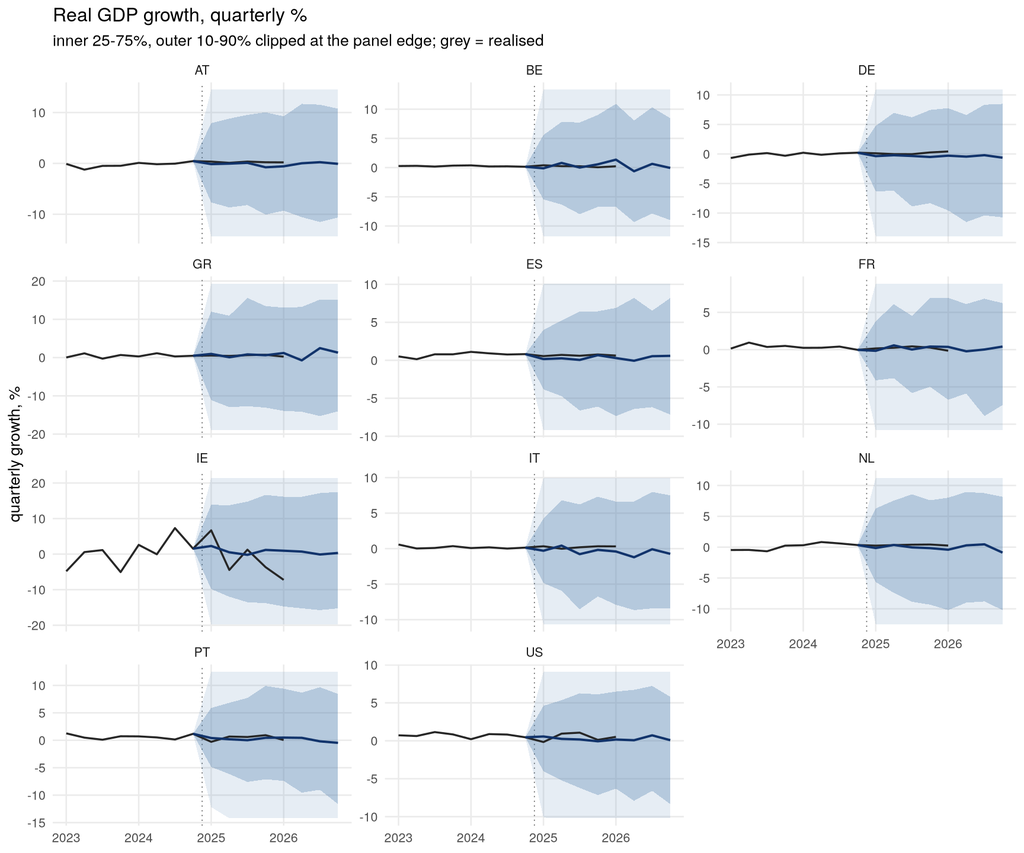

Median GDP growth forecast by quarter, percent.

| quarter | AT | BE | DE | GR | ES | FR | IE | IT | NL | PT | US |
| --- | --- | --- | --- | --- | --- | --- | --- | --- | --- | --- | --- |
| 2025Q1 | -0.14 | -0.12 | -0.36 | 0.95 | 0.16 | -0.16 | 2.29 | -0.30 | -0.14 | 0.41 | 0.56 |
| 2025Q2 | -0.04 | 0.80 | -0.21 | 0.08 | 0.26 | 0.57 | 0.51 | 0.42 | 0.35 | 0.19 | 0.25 |
| 2025Q3 | 0.11 | 0.01 | -0.33 | 0.82 | 0.05 | 0.02 | -0.21 | -0.77 | -0.04 | 0.01 | 0.17 |
| 2025Q4 | -0.76 | 0.56 | -0.51 | 0.61 | 0.67 | 0.41 | 1.18 | -0.18 | -0.16 | 0.45 | -0.07 |
| 2026Q1 | -0.57 | 1.36 | -0.29 | 1.19 | 0.29 | 0.37 | 0.95 | -0.40 | -0.41 | 0.49 | 0.16 |
| 2026Q2 | 0.03 | -0.63 | -0.45 | -0.73 | -0.06 | -0.22 | 0.71 | -1.21 | 0.29 | 0.44 | 0.07 |
| 2026Q3 | 0.24 | 0.64 | -0.20 | 2.46 | 0.54 | 0.02 | -0.10 | -0.09 | 0.46 | -0.19 | 0.72 |
| 2026Q4 | -0.09 | -0.06 | -0.63 | 1.29 | 0.58 | 0.41 | 0.32 | -0.73 | -0.89 | -0.47 | 0.08 |

### Prices

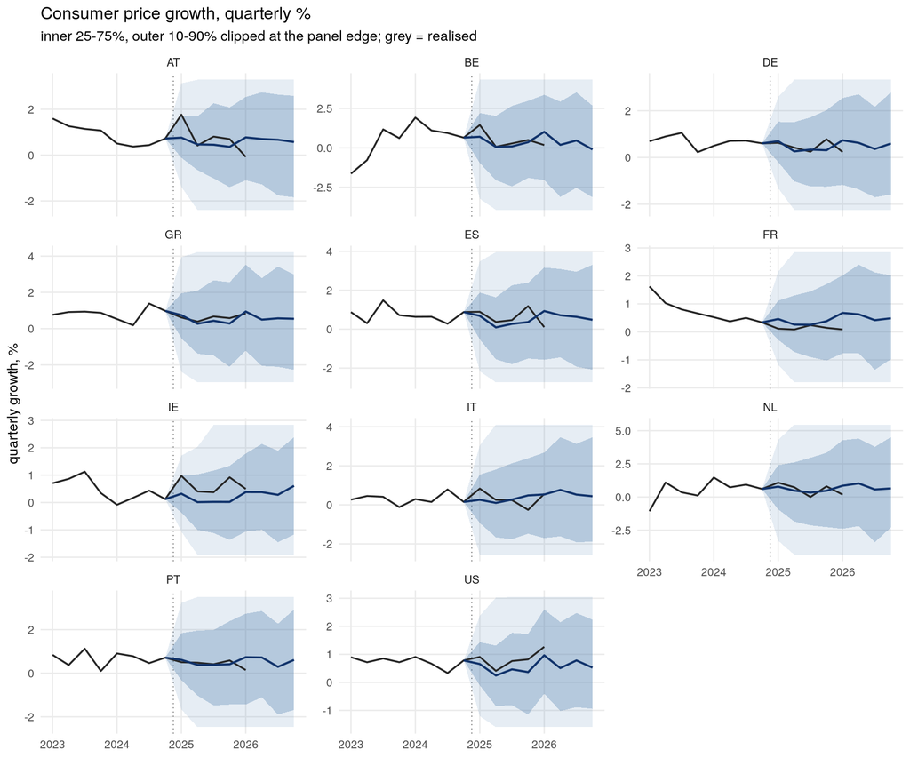

Median price growth forecast by quarter, percent.

| quarter | AT | BE | DE | GR | ES | FR | IE | IT | NL | PT | US |
| --- | --- | --- | --- | --- | --- | --- | --- | --- | --- | --- | --- |
| 2025Q1 | 0.76 | 0.70 | 0.70 | 0.74 | 0.68 | 0.46 | 0.32 | 0.26 | 0.78 | 0.61 | 0.65 |
| 2025Q2 | 0.47 | 0.06 | 0.26 | 0.27 | 0.09 | 0.26 | 0.01 | 0.10 | 0.48 | 0.38 | 0.24 |
| 2025Q3 | 0.45 | 0.09 | 0.34 | 0.43 | 0.27 | 0.25 | 0.02 | 0.27 | 0.34 | 0.38 | 0.46 |
| 2025Q4 | 0.36 | 0.36 | 0.31 | 0.28 | 0.36 | 0.38 | 0.02 | 0.48 | 0.47 | 0.41 | 0.37 |
| 2026Q1 | 0.77 | 1.01 | 0.73 | 0.94 | 0.93 | 0.68 | 0.38 | 0.53 | 0.85 | 0.73 | 0.96 |
| 2026Q2 | 0.70 | 0.19 | 0.62 | 0.49 | 0.71 | 0.63 | 0.38 | 0.77 | 1.03 | 0.72 | 0.51 |
| 2026Q3 | 0.67 | 0.46 | 0.36 | 0.57 | 0.63 | 0.42 | 0.28 | 0.52 | 0.57 | 0.29 | 0.78 |
| 2026Q4 | 0.57 | -0.10 | 0.60 | 0.54 | 0.48 | 0.49 | 0.61 | 0.44 | 0.65 | 0.61 | 0.53 |

### Policy rates

A `method = "none"` series passes through koma untouched, so for a policy rate the forecast **is** the level – there is no rate-versus-level distinction to make, and no anchoring question either.

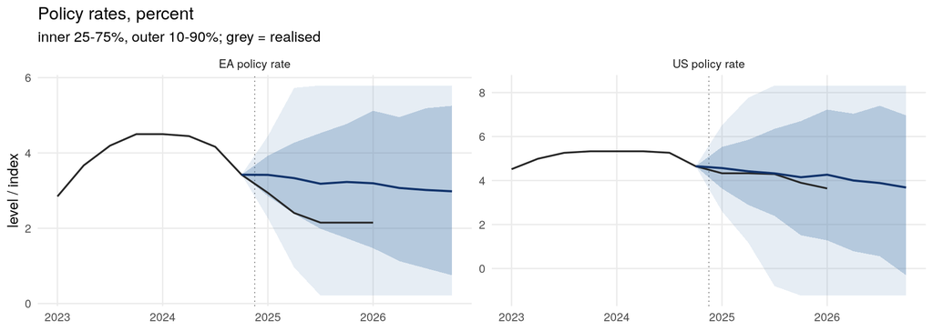

Median policy-rate path, percent.

| quarter | ea_policy_rate | us_policy_rate |
| --- | --- | --- |
| 2025Q1 | 3.42 | 4.57 |
| 2025Q2 | 3.33 | 4.42 |
| 2025Q3 | 3.18 | 4.33 |
| 2025Q4 | 3.23 | 4.15 |
| 2026Q1 | 3.19 | 4.26 |
| 2026Q2 | 3.07 | 4.00 |
| 2026Q3 | 3.02 | 3.89 |
| 2026Q4 | 2.98 | 3.68 |

### What was discarded, and what the exogenous path assumes

Share of posterior draws discarded as explosive, by variable.

| variable | explosive share, h1 | h8 | max |
| --- | --- | --- | --- |
| gr_gdp | 0.060 | 0.610 | 0.610 |
| at_gdp | 0.056 | 0.569 | 0.569 |
| nl_gdp | 0.024 | 0.561 | 0.561 |
| it_gdp | 0.027 | 0.560 | 0.560 |
| de_gdp | 0.036 | 0.557 | 0.557 |
| be_gdp | 0.038 | 0.554 | 0.554 |
| pt_gdp | 0.023 | 0.541 | 0.541 |
| ie_gdp | 0.022 | 0.531 | 0.531 |
| es_gdp | 0.016 | 0.525 | 0.525 |
| fr_gdp | 0.035 | 0.522 | 0.522 |
| us_gdp | 0.026 | 0.491 | 0.491 |
| be_prices | 0.009 | 0.458 | 0.458 |
| nl_prices | 0.004 | 0.448 | 0.448 |
| gr_prices | 0.004 | 0.439 | 0.439 |
| es_prices | 0.005 | 0.424 | 0.424 |
| it_prices | 0.005 | 0.421 | 0.421 |
| at_prices | 0.003 | 0.418 | 0.418 |
| fr_prices | 0.004 | 0.412 | 0.412 |
| de_prices | 0.001 | 0.409 | 0.409 |
| pt_prices | 0.002 | 0.406 | 0.406 |
| us_prices | 0.003 | 0.383 | 0.383 |
| ie_prices | 0.000 | 0.330 | 0.330 |

The untruncated predictive band at horizon 8 – quarterly growth, percent. This is what the charts clip.

| variable | median | inner_low | inner_high | outer_low | outer_high | outer_width |
| --- | --- | --- | --- | --- | --- | --- |
| at_gdp | -0.1 | -10.6 | 10.8 | -34.2 | 29.0 | 63.2 |
| be_gdp | -0.1 | -9.0 | 8.5 | -26.7 | 34.2 | 60.9 |
| de_gdp | -0.6 | -10.7 | 8.5 | -31.6 | 28.5 | 60.1 |
| gr_gdp | 1.3 | -14.0 | 15.1 | -37.1 | 39.5 | 76.6 |
| es_gdp | 0.6 | -7.1 | 8.2 | -28.2 | 26.8 | 55.0 |
| fr_gdp | 0.4 | -7.4 | 6.2 | -31.6 | 31.0 | 62.6 |
| ie_gdp | 0.3 | -15.3 | 17.5 | -35.4 | 34.5 | 69.9 |
| it_gdp | -0.7 | -8.4 | 7.5 | -29.7 | 23.6 | 53.3 |
| nl_gdp | -0.9 | -10.2 | 8.2 | -29.5 | 27.1 | 56.6 |
| pt_gdp | -0.5 | -11.6 | 8.4 | -33.1 | 27.3 | 60.4 |
| us_gdp | 0.1 | -8.3 | 5.8 | -33.0 | 18.1 | 51.1 |
| at_prices | 0.6 | -1.8 | 2.6 | -9.7 | 10.8 | 20.5 |
| be_prices | -0.1 | -3.1 | 2.7 | -14.4 | 11.6 | 26.0 |
| de_prices | 0.6 | -1.6 | 2.8 | -9.8 | 12.5 | 22.3 |
| gr_prices | 0.5 | -2.3 | 3.0 | -12.7 | 12.9 | 25.6 |
| es_prices | 0.5 | -2.1 | 3.3 | -12.8 | 16.9 | 29.7 |
| fr_prices | 0.5 | -1.0 | 2.0 | -10.6 | 11.3 | 21.9 |
| ie_prices | 0.6 | -1.2 | 2.4 | -5.0 | 6.6 | 11.6 |
| it_prices | 0.4 | -1.9 | 3.5 | -16.9 | 15.4 | 32.3 |
| nl_prices | 0.6 | -2.3 | 4.5 | -16.5 | 16.4 | 32.9 |
| pt_prices | 0.6 | -1.7 | 2.9 | -10.6 | 14.0 | 24.6 |
| us_prices | 0.5 | -0.9 | 2.2 | -9.3 | 8.0 | 17.3 |

A forecast this long needs the **exogenous** series to reach the end of the horizon, and they do not: every one of them stops at the fit’s own native forecast end. `extend_forecast_horizon()` carries each one forward on its trailing four-quarter average growth – a momentum continuation, not a view on oil markets or world trade – and koma would otherwise have silently returned a shorter horizon than the one requested.

How each exogenous series was carried past the fit’s native forecast end.

| variable | method | periods_added |
| --- | --- | --- |
| covid_2020q1 | zero (dummy) | 3 |
| covid_2020q2 | zero (dummy) | 3 |
| covid_2020q3 | zero (dummy) | 3 |
| covid_2021q2 | zero (dummy) | 3 |
| eur_usd | trailing-4Q avg growth (2.67%/q) | 3 |
| oil_price | trailing-4Q avg growth (1.41%/q) | 3 |
| row_gdp | trailing-4Q avg growth (0.72%/q) | 3 |